For Data Preperation, Data Analysis and Data Exploration

```python
import pandas as pd # importing pandas and using alias, namimg it as "pd"
import numpy as np # importing numpy and using alias, naming it as "np"
import matplotlib.pyplot as plt # importing matlpotlib.plt  and using alias, naming it as "plt"
```

# i. Data Preperation

1) Write a python program to load data into pandas DataFrame

```python
data = pd.read_csv("DataScienceSalaries_8b290669-a5e9-45bf-be72-d27add2eacae_93472_.csv")
# Reading the csv file from local storage
```

```python
dataFrame = pd.DataFrame(data)
# Converting the csv files into DataFrame for clear analyzing
```

```python
dataFrame.head() # printing the dataFrame
```

|  | work_year | experience_level | employment_type | job_title | salary | salary_currency | salary_in_usd | employee_residence | remote_ratio | company_location | company_size |
| --- | --- | --- | --- | --- | --- | --- | --- | --- | --- | --- | --- |
| 0 | 2023 | SE | FT | Principal Data Scientist | 80000 | EUR | 85847 | ES | 100 | ES | L |
| 1 | 2023 | MI | CT | ML Engineer | 30000 | USD | 30000 | US | 100 | US | S |
| 2 | 2023 | MI | CT | ML Engineer | 25500 | USD | 25500 | US | 100 | US | S |
| 3 | 2023 | SE | FT | Data Scientist | 175000 | USD | 175000 | CA | 100 | CA | M |
| 4 | 2023 | SE | FT | Data Scientist | 120000 | USD | 120000 | CA | 100 | CA | M |

2) Write a python program to remove unnecessary columns i.e., salary and salary currency.

```python
# List of columns to exclude from the new DataFram
column_to_exclude = ["salary", "salary_currency"]

# List to store columns to keep
column_to_keep = []

# Iterating through columns in the new DataFrame
for col in dataFrame.columns:
    # Checking if the column is not in the exclusion list
    if col not in column_to_exclude:
        column_to_keep.append(col) # If the column is not excluded, add it to the list of columns to keep

# Printing the list of columns to keep
print(column_to_keep)

# Creating a new DataFrame by dropping the excluded columns'
dropped_columns = dataFrame[column_to_keep]
dataFrame = dropped_columns
```

```
['work_year', 'experience_level', 'employment_type', 'job_title', 'salary_in_usd', 'employee_residence', 'remote_ratio', 'company_location', 'company_size']
```

3) Write a python program to remove the NaN missing values from updated dataframe.

```python
# checking if there is any nan values in the dataFrame
has_null = dataFrame.isnull().values.any()
print(has_null)

# If there were any NaN values in the DataFrame, 'has_null' would be True,
# indicating the presence of missing data. However, since there are no NaN values,
# 'has_null' is False, indicating that the DataFrame contains no missing data.

dataFrame.dropna(inplace=True)
# To remove rows containing NaN values from the DataFrame, we can use the dropna() function.
# This function returns a new DataFrame with NaN values dropped.
dataFrame
```

```
False
```

|  | work_year | experience_level | employment_type | job_title | salary_in_usd | employee_residence | remote_ratio | company_location | company_size |
| --- | --- | --- | --- | --- | --- | --- | --- | --- | --- |
| 0 | 2023 | SE | FT | Principal Data Scientist | 85847 | ES | 100 | ES | L |
| 1 | 2023 | MI | CT | ML Engineer | 30000 | US | 100 | US | S |
| 2 | 2023 | MI | CT | ML Engineer | 25500 | US | 100 | US | S |
| 3 | 2023 | SE | FT | Data Scientist | 175000 | CA | 100 | CA | M |
| 4 | 2023 | SE | FT | Data Scientist | 120000 | CA | 100 | CA | M |
| ... | ... | ... | ... | ... | ... | ... | ... | ... | ... |
| 3750 | 2020 | SE | FT | Data Scientist | 412000 | US | 100 | US | L |
| 3751 | 2021 | MI | FT | Principal Data Scientist | 151000 | US | 100 | US | L |
| 3752 | 2020 | EN | FT | Data Scientist | 105000 | US | 100 | US | S |
| 3753 | 2020 | EN | CT | Business Data Analyst | 100000 | US | 100 | US | L |
| 3754 | 2021 | SE | FT | Data Science Manager | 94665 | IN | 50 | IN | L |

3755 rows × 9 columns

4) Write a python program to check duplicate value in the dataFrame

```python
print("Duplicates:", dataFrame.duplicated())

# Initializing a set to store seen rows and a list to store duplicate indices
seen = set()
duplicate_indices = []

# Iterating through rows in the DataFrame
for index, row in dataFrame.iterrows():
    # Converting the row to a tuple for comparison
    row_tuple = tuple(row)
    # Checking if the row has been seen before
    if row_tuple in seen:
        # If the row is a duplicate, adding its index to the list of duplicate indices
        duplicate_indices.append(index)
    else:
        # If the row is not a duplicate, adding it to the set of seen rows
        seen.add(row_tuple)

# Printing the indices of duplicate rows
print(duplicate_indices)

# Dropping duplicate rows from the DataFrame
dataFrame.drop_duplicates(inplace=True)

# Printing whether there are any duplicated rows after removing duplicates
print("Duplicates:", dataFrame.duplicated().any())
```

```
Duplicates: 0       False
1       False
2       False
3       False
4       False
        ...
3750    False
3751    False
3752    False
3753    False
3754    False
Length: 3755, dtype: bool
[115, 123, 153, 154, 160, 163, 164, 167, 168, 171, 173, 174, 189, 195, 201, 206, 223, 224, 225, 226, 227, 235, 250, 251, 258, 264, 265, 273, 276, 277, 284, 285, 288, 290, 291, 294, 295, 302, 309, 330, 331, 332, 333, 340, 341, 345, 348, 349, 352, 353, 374, 379, 380, 382, 384, 393, 394, 395, 396, 401,…
Duplicates: False
```

5) Write a python program to see the unique values from all the columns in the dataframe.

```python
# Printing unique values for each column in the DataFrame
for column in dataFrame.columns:
    print(dataFrame[column].unique())
```

```
[2023 2022 2020 2021]
['SE' 'MI' 'EN' 'EX']
['FT' 'CT' 'FL' 'PT']
['Principal Data Scientist' 'ML Engineer' 'Data Scientist'
 'Applied Scientist' 'Data Analyst' 'Data Modeler' 'Research Engineer'
 'Analytics Engineer' 'Business Intelligence Engineer'
 'Machine Learning Engineer' 'Data Strategist' 'Data Engineer'
 'Computer Vision Engineer' 'Data Quality Analyst'
 'Compliance Data Analyst' 'Data Architect'
 'Applied Machine Learning Engineer' 'AI Developer' 'Research Scientist'
 'Data Analytics Manager' 'Business Data Analyst' 'Applied Data Scientist'
 'Staff Data Analyst' 'ETL Engineer' 'Data DevOps Engineer' 'Head of Data'
 'Data Science Manager' 'Data Manager' 'Machine Learning Researcher'
 'Big Data Engineer' 'Data Specialist' 'Lead Data Analyst'
 'BI Data Engineer' 'Director of Data Science'
 'Machine Learning Scientist' 'MLOps Engineer' 'AI Scientist'
 'Autonomous Vehicle Technician' 'Applied Machine Learning Scientist'
 'Lead Data Scientist' 'Cloud Database Engineer' 'Financial Data Analyst'
 'Data Infrastructure Engineer' 'Software Data Engineer' 'AI Programmer'
 'Data Operations Engineer' 'BI Developer' 'Data Science Lead'
 'Deep Learning Researcher' 'BI Analyst' 'Data Science Consultant'
 'Data Analytics Specialist' 'Machine Learning Infrastructure Engineer'
 'BI Data Analyst' 'Head of Data Science' 'Insight Analyst'
 'Deep Learning Engineer' 'Machine Learning Software Engineer'
 'Big Data Architect' 'Product Data Analyst'
 'Computer Vision Software Engineer' 'Azure Data Engineer'
 'Marketing Data Engineer' 'Data Analytics Lead' 'Data Lead'
 'Data Science Engineer' 'Machine Learning Research Engineer'
 'NLP Engineer' 'Manager Data Management' 'Machine Learning Developer'
 '3D Computer Vision Researcher' 'Principal Machine Learning Engineer'
 'Data Analytics Engineer' 'Data Analytics Consultant'
 'Data Management Specialist' 'Data Science Tech Lead'
 'Data Scientist Lead' 'Cloud Data Engineer' 'Data Operations Analyst'
 'Marketing Data Analyst' 'Power BI Developer' 'Product Data Scientist'
 'Principal Data Architect' 'Machine Learning Manager'
 'Lead Machine Learning Engineer' 'ETL Developer' 'Cloud Data Architect'
 'Lead Data Engineer' 'Head of Machine Learning' 'Principal Data Analyst'
 'Principal Data Engineer' 'Staff Data Scientist' 'Finance Data Analyst']
[ 85847  30000  25500 ...  28369 412000  94665]
['ES' 'US' 'CA' 'DE' 'GB' 'NG' 'IN' 'HK' 'PT' 'NL' 'CH' 'CF' 'FR' 'AU'
 'FI' 'UA' 'IE' 'IL' 'GH' 'AT' 'CO' 'SG' 'SE' 'SI' 'MX' 'UZ' 'BR' 'TH'
 'HR' 'PL' 'KW' 'VN' 'CY' 'AR' 'AM' 'BA' 'KE' 'GR' 'MK' 'LV' 'RO' 'PK'
 'IT' 'MA' 'LT' 'BE' 'AS' 'IR' 'HU' 'SK' 'CN' 'CZ' 'CR' 'TR' 'CL' 'PR'
 'DK' 'BO' 'PH' 'DO' 'EG' 'ID' 'AE' 'MY' 'JP' 'EE' 'HN' 'TN' 'RU' 'DZ'
 'IQ' 'BG' 'JE' 'RS' 'NZ' 'MD' 'LU' 'MT']
[100   0  50]
['ES' 'US' 'CA' 'DE' 'GB' 'NG' 'IN' 'HK' 'NL' 'CH' 'CF' 'FR' 'FI' 'UA'
 'IE' 'IL' 'GH' 'CO' 'SG' 'AU' 'SE' 'SI' 'MX' 'BR' 'PT' 'RU' 'TH' 'HR'
 'VN' 'EE' 'AM' 'BA' 'KE' 'GR' 'MK' 'LV' 'RO' 'PK' 'IT' 'MA' 'PL' 'AL'
 'AR' 'LT' 'AS' 'CR' 'IR' 'BS' 'HU' 'AT' 'SK' 'CZ' 'TR' 'PR' 'DK' 'BO'
 'PH' 'BE' 'ID' 'EG' 'AE' 'LU' 'MY' 'HN' 'JP' 'DZ' 'IQ' 'CN' 'NZ' 'CL'
 'MD' 'MT']
['L' 'S' 'M']
```

6) Rename the experience level columns as below.  
SE – Senior Level/Expert MI – Medium Level/Intermediate EN – Entry Level EX – Executive Level

```python
# Mapping experience level abbreviations to descriptive labels and replacing them in the DataFrame
experience_level_mapping = {
    "SE": "Senior Level/Expert",
    "MI": "Medium Level/Intermediate",
    "EN": "Entry Level",
    "EX": "Executive Level"
}

# Replacing the values in the "experience_level" column with their corresponding labels
# inplace=True modifies the DataFrame in place
dataFrame["experience_level"].replace(experience_level_mapping, inplace=True)

dataFrame.head()
```

|  | work_year | experience_level | employment_type | job_title | salary_in_usd | employee_residence | remote_ratio | company_location | company_size |
| --- | --- | --- | --- | --- | --- | --- | --- | --- | --- |
| 0 | 2023 | Senior Level/Expert | FT | Principal Data Scientist | 85847 | ES | 100 | ES | L |
| 1 | 2023 | Medium Level/Intermediate | CT | ML Engineer | 30000 | US | 100 | US | S |
| 2 | 2023 | Medium Level/Intermediate | CT | ML Engineer | 25500 | US | 100 | US | S |
| 3 | 2023 | Senior Level/Expert | FT | Data Scientist | 175000 | CA | 100 | CA | M |
| 4 | 2023 | Senior Level/Expert | FT | Data Scientist | 120000 | CA | 100 | CA | M |

# ii) Data Analysis

1) Write a Python program to show summary statistics of sum, mean, standard deviation, skewness, and kurtosis of any chosen variable

```python
salary_column = dataFrame["salary_in_usd"] # Extracting the "salary_in_usd" column

total_sum = 0

# Iterating through each salary value in the column and adding it to the total sum
for i in salary_column:
    total_sum = total_sum + i

total_sum # value from the calculation
```

```
344729580
```

```python
# Dividing the total sum by number of rows in the salary_in_usd column to get mean value
salary_mean = total_sum / len(salary_column)

salary_mean # value from the calculation
```

```
133409.28018575851
```

```python
squared_deviations = 0 # Initializing variable for sum of squared deviations

#Calculating the sum of squared deviations for each salary value from the mean.
for x in salary_column:
    deviation = x - salary_mean
    squared_deviation = deviation ** 2
    squared_deviations += squared_deviation

data_variance = squared_deviations / len(salary_column) # Calculating the data variance

salary_standard_deviation = data_variance ** 0.5 # Calculating the standard deviation by taking the square root of the variance

print(salary_standard_deviation) # printing the value
salary_column.std()
```

```
67123.84519805372
```

```
67136.83732925021
```

```python
cubed_deviations = 0  #Initializing the sum of cubed deviations

# Calculating the sum of cubed deviations
for x in salary_column:
    deviation = x - salary_mean
    cube_deviation = deviation ** 3
    cubed_deviations = cube_deviation + cubed_deviations

#Calculating the skewness of salary values
salary_skew = cubed_deviations / len(salary_column) / (salary_standard_deviation ** 3)

salary_skew
```

```
0.6199567299104844
```

```python
pow_deviations = 0 # Initializing the sum of fourth power deviations

# Calculating the sum of fourth power deviations
for x in salary_column:
    deviation = x - salary_mean
    pow_deviation = deviation ** 4
    pow_deviations = pow_deviations + pow_deviation

 # Calculating the kurtosis of salary values
salary_kurtosis = pow_deviations / len(salary_column) / (salary_standard_deviation ** 4)

salary_kurtosis # Printing the kurtosis of salary values
```

```
3.823019754941828
```

2) Write a Python program to calculate and show correlation of all variables.

```python
int_columns = dataFrame.select_dtypes(include=['int64'])
print(int_columns.head())
int_columns.corr()
```

```
   work_year  salary_in_usd  remote_ratio
0       2023          85847           100
1       2023          30000           100
2       2023          25500           100
3       2023         175000           100
4       2023         120000           100
```

|  | work_year | salary_in_usd | remote_ratio |
| --- | --- | --- | --- |
| work_year | 1.000000 | 0.236958 | -0.219160 |
| salary_in_usd | 0.236958 | 1.000000 | -0.084502 |
| remote_ratio | -0.219160 | -0.084502 | 1.000000 |

# iii) Data Exploration

1) Write a python program to find out top 15 jobs. Make a bar graph of sales as well.

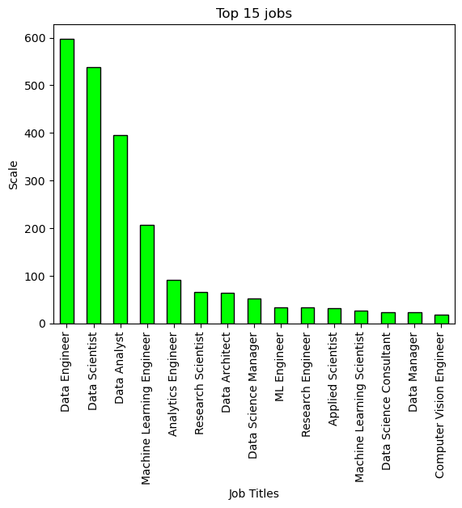

```python
top_jobs = dataFrame["job_title"].value_counts().head(15) #Extracting the top 15 most common job titles and their frequencies
top_jobs

top_jobs.plot(kind="bar", color="lime" ,edgecolor="black")

# Displaying the top jobs as a bar plot
plt.title("Top 15 jobs")
plt.xlabel("Job Titles")
plt.ylabel("Scale")

plt.show()
```

2) Which job has the highest salaries? Illustrate with bar graph.

```
Job with the highest average salary: Data Science Tech Lead with an average of $375000.00
```

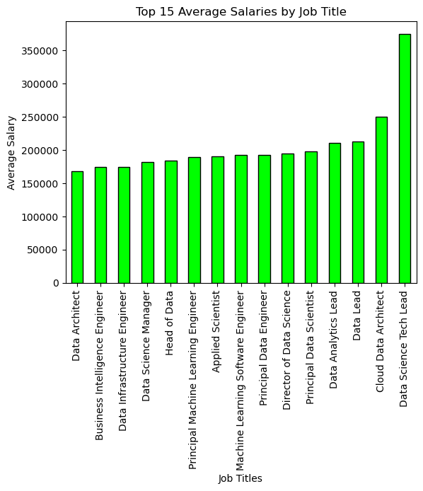

```python
# Grouping the DataFrame by job title and calculating the average salary for each job
avarage_salary_by_job = dataFrame.groupby('job_title')["salary_in_usd"].mean()

# Finding the job with the highest average salary
highest_salary_job = avarage_salary_by_job.idxmax()
print(f"Job with the highest average salary: {highest_salary_job} with an average of ${avarage_salary_by_job.max():.2f}")


# Adding title and labels to the plot
avarage_salary_by_job.sort_values().tail(15).plot(kind='bar', color="Lime" ,edgecolor="black")
plt.title('Top 15 Average Salaries by Job Title')
plt.xlabel('Job Titles')
plt.ylabel('Average Salary')
plt.show()
```

3) Write a python program to find out salaries based on experience level. Illustrate it through bar graph.

```
experience_level
Entry Level                   72648.685185
Executive Level              191078.208333
Medium Level/Intermediate    101828.783133
Senior Level/Expert          153897.435650
Name: salary_in_usd, dtype: float64
```

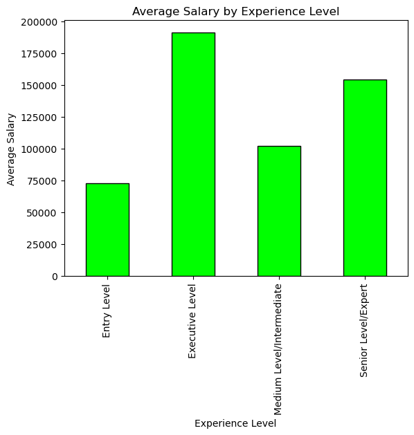

```python
# Grouping the DataFrame by experience level and calculating the average salary for each experience level
average_salary_by_experience = dataFrame.groupby('experience_level')['salary_in_usd'].mean()
print(average_salary_by_experience)


# Adding title and labels to the plot
average_salary_by_experience.plot(kind='bar',color="Lime" ,edgecolor= "black")
plt.title('Average Salary by Experience Level')
plt.xlabel('Experience Level')
plt.ylabel('Average Salary')
plt.show()
```

4) Write a Python program to show histogram and box plot of any chosen different variables. Use proper labels in the graph.

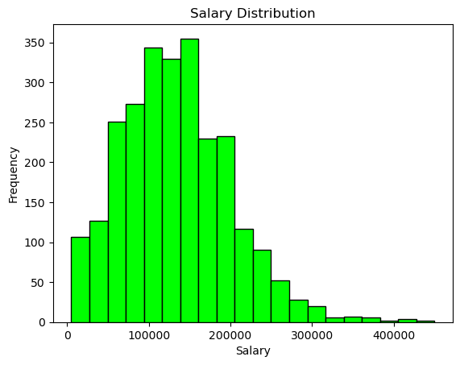

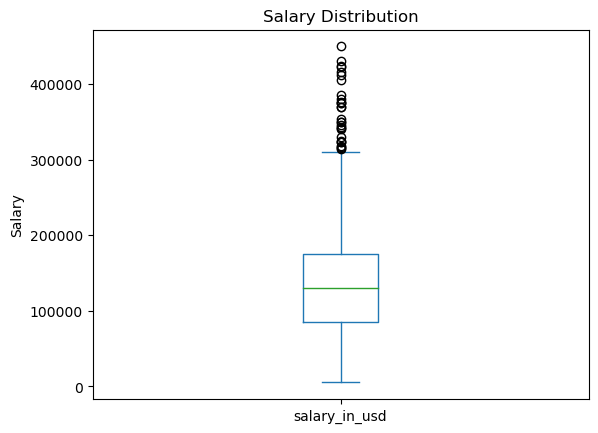

```python
# Plotting a histogram to visualize the distribution of salaries
dataFrame["salary_in_usd"].plot(kind= "hist", bins=20, edgecolor="black" ,color="Lime")
plt.title('Salary Distribution')
plt.xlabel('Salary')
plt.ylabel('Frequency')
plt.show()


# Plotting a box plot to visualize the distribution of salaries
dataFrame['salary_in_usd'].plot(kind='box')
plt.title('Salary Distribution')
plt.ylabel('Salary')
plt.show()
```

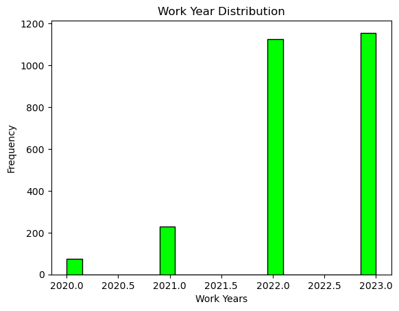

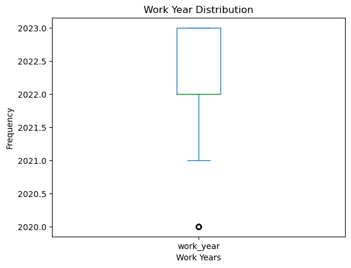

```python
# Plotting a histogram to visualize the distribution of salaries
dataFrame["work_year"].plot(kind= "hist", bins=20, edgecolor="black" ,color="Lime")
plt.title('Work Year Distribution')
plt.xlabel('Work Years')
plt.ylabel('Frequency')
plt.show()


# Plotting a box plot to visualize the distribution of salaries
dataFrame['work_year'].plot(kind='box')
plt.title('Work Year Distribution')
plt.xlabel('Work Years')
plt.ylabel('Frequency')
plt.show()
```